# Elsevier 2022 SDG mapping

# General to all SDGs

## Introduction

The United Nations Sustainable Development Goals (SDGs) challenge the global community to build a world where no one is left behind.

Since 2018, Elsevier has generated SDG search queries to help researchers and institutions track and demonstrate progress toward the SDG targets. In the past 3 years, these queries, along with the university’s own data and evidence supporting progress and contributions to the particular SDG outside of research-based metrics, are used for the THE Impact Rankings.

## Method

For 2022, this SDG uses the exact same search query and ML algorithm as the Elsevier 2021 SDG mapping. [Full details of the 2021 methodology are available on Digital Commons Data.](https://elsevier.digitalcommonsdata.com/datasets/9sxdykm8s4/4)

# [SDG 12 - Ensure sustainable consumption and production patterns](https://sdgs.un.org/goals/goal12)

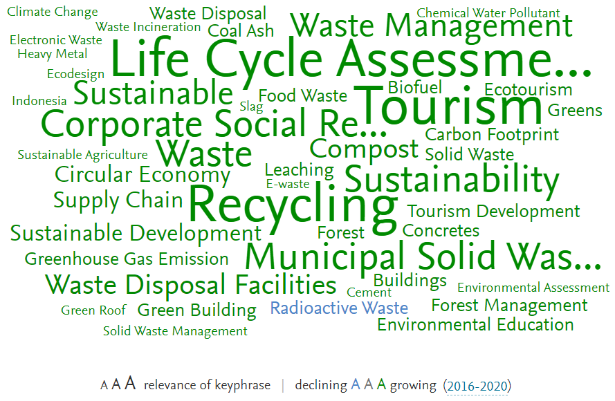

Explore this wordcloud plus the most active contributors on the [SciVal SDG site](https://scival.com/sdg)

## Query

Below is the full search query used for this SDG. We’ve broken it down by each query component. Use the + and – to concatenate the different bracket levels.

(

(

TITLE

(

"LCA"

)

OR TITLE-ABS

(

"forest stewardship"

)

OR AUTHKEY

(

"forest stewardship"

)

OR TITLE-ABS

(

"life cycle inventory"

)

OR AUTHKEY

(

"life cycle inventory"

)

OR TITLE-ABS

(

"sustainable intensification"

)

OR AUTHKEY

(

"sustainable intensification"

)

OR TITLE-ABS

(

"ecological* building*"

)

OR AUTHKEY

(

"ecological* building*"

)

OR TITLE-ABS

(

"sustainable original harvest"

)

OR AUTHKEY

(

"sustainable original harvest"

)

OR

(

TITLE-ABS

(

"zero-energy housing"

)

OR TITLE-ABS

(

"zeroenergy housing"

)

)

OR

(

AUTHKEY

(

"zero-energy housing"

)

OR AUTHKEY

(

"zeroenergy housing"

)

)

OR

(

TITLE-ABS

(

"carbon footprint"

)

AND

(

TITLE-ABS("production") OR TITLE-ABS("consumption") OR TITLE-ABS("manufacturing") OR TITLE-ABS("procurement") OR TITLE-ABS("producer*") OR TITLE-ABS("consumer*")

)

)

OR

(

AUTHKEY

(

"carbon footprint"

)

AND

(

AUTHKEY("production") OR AUTHKEY("consumption") OR AUTHKEY("manufacturing") OR AUTHKEY("procurement") OR AUTHKEY("producer*") OR AUTHKEY("consumer*")

)

)

OR

(

TITLE-ABS

(

"recycled plastic"

)

AND

(

TITLE-ABS("construction") OR TITLE-ABS("building*") OR TITLE-ABS("architecture") OR TITLE-ABS("housing") OR TITLE-ABS("infrastructure")

)

)

OR

(

AUTHKEY

(

"recycled plastic"

)

AND

(

AUTHKEY("construction") OR AUTHKEY("building*") OR AUTHKEY("architecture") OR AUTHKEY("housing") OR AUTHKEY("infrastructure")

)

)

OR TITLE-ABS

(

"sustainable* construction*"

)

OR AUTHKEY

(

"sustainable* construction*"

)

OR TITLE-ABS

(

"green building material"

)

OR AUTHKEY

(

"green building material"

)

OR TITLE-ABS

(

"sustainable architecture"

)

OR AUTHKEY

(

"sustainable architecture"

)

OR TITLE-ABS

(

"sustainable forest management"

)

OR AUTHKEY

(

"sustainable forest management"

)

OR

(

TITLE-ABS

(

"eco-construction materials"

)

OR TITLE-ABS

(

"ecoconstruction materials"

)

)

OR

(

AUTHKEY

(

"eco-construction materials"

)

OR AUTHKEY

(

"ecoconstruction materials"

)

)

OR TITLE-ABS

(

"FSC certification"

)

OR AUTHKEY

(

"FSC certification"

)

OR TITLE-ABS

(

"industrial ecology"

)

OR AUTHKEY

(

"industrial ecology"

)

OR TITLE-ABS

(

"Leadership in Energy and Environmental Design"

)

OR AUTHKEY

(

"Leadership in Energy and Environmental Design"

)

OR TITLE-ABS

(

"green building materials"

)

OR AUTHKEY

(

"green building materials"

)

OR TITLE-ABS

(

"ecolabel"

)

OR AUTHKEY

(

"ecolabel"

)

OR TITLE-ABS

(

"forest management"

)

OR AUTHKEY

(

"forest management"

)

OR TITLE-ABS

(

"sustainable production and consumption"

)

OR AUTHKEY

(

"sustainable production and consumption"

)

OR

(

TITLE-ABS

(

"resource* efficien*"

)

AND TITLE-ABS

(

"industry"

)

)

OR

(

AUTHKEY

(

"resource* efficien*"

)

AND AUTHKEY

(

"industry"

)

)

OR

(

TITLE-ABS

(

"zero carbon"

)

AND

(

TITLE-ABS("construction") OR TITLE-ABS("building*") OR TITLE-ABS("architecture") OR TITLE-ABS("housing") OR TITLE-ABS("infrastructure")

)

)

OR

(

AUTHKEY

(

"zero carbon"

)

AND

(

AUTHKEY("construction") OR AUTHKEY("building*") OR AUTHKEY("architecture") OR AUTHKEY("housing") OR AUTHKEY("infrastructure")

)

)

OR TITLE-ABS

(

"life cycle greenhouse gas emissions"

)

OR AUTHKEY

(

"life cycle greenhouse gas emissions"

)

OR

(

TITLE-ABS

(

"sustainable timber"

)

AND

(

TITLE-ABS("construction") OR TITLE-ABS("building*") OR TITLE-ABS("architecture") OR TITLE-ABS("housing") OR TITLE-ABS("infrastructure")

)

)

OR

(

AUTHKEY

(

"sustainable timber"

)

AND

(

AUTHKEY("construction") OR AUTHKEY("building*") OR AUTHKEY("architecture") OR AUTHKEY("housing") OR AUTHKEY("infrastructure")

)

)

OR

(

TITLE-ABS

(

"sustainable"

)

AND TITLE-ABS

(

"supply* chain*"

)

)

OR

(

AUTHKEY

(

"sustainable"

)

AND AUTHKEY

(

"supply* chain*"

)

)

OR

(

(

(TITLE-ABS("green design") OR TITLE-ABS("ecological design") OR TITLE-ABS("eco-design")) AND (TITLE-ABS("house") OR TITLE-ABS("buildings") OR TITLE-ABS("houses") OR TITLE-ABS("infrastructure"))

)

OR

(

(TITLE-ABS("green design") OR TITLE-ABS("ecological design") OR TITLE-ABS("ecodesign")) AND (TITLE-ABS("house") OR TITLE-ABS("buildings") OR TITLE-ABS("houses") OR TITLE-ABS("infrastructure"))

)

)

OR

(

(

(AUTHKEY("green design") OR AUTHKEY("ecological design") OR AUTHKEY("eco-design")) AND (AUTHKEY("house") OR AUTHKEY("buildings") OR AUTHKEY("houses") OR AUTHKEY("infrastructure"))

)

OR

(

(AUTHKEY("green design") OR AUTHKEY("ecological design") OR AUTHKEY("ecodesign")) AND (AUTHKEY("house") OR AUTHKEY("buildings") OR AUTHKEY("houses") OR AUTHKEY("infrastructure"))

)

)

OR

(

(

TITLE-ABS("environmentally-friendly materials") AND (TITLE-ABS("construction") OR TITLE-ABS("building*") OR TITLE-ABS("architecture") OR TITLE-ABS("housing") OR TITLE-ABS("infrastructure"))

)

OR

(

TITLE-ABS("environmentallyfriendly materials") AND (TITLE-ABS("construction") OR TITLE-ABS("building*") OR TITLE-ABS("architecture") OR TITLE-ABS("housing") OR TITLE-ABS("infrastructure"))

)

)

OR

(

(

AUTHKEY("environmentally-friendly materials") AND (AUTHKEY("construction") OR AUTHKEY("building*") OR AUTHKEY("architecture") OR AUTHKEY("housing") OR AUTHKEY("infrastructure"))

)

OR

(

AUTHKEY("environmentallyfriendly materials") AND (AUTHKEY("construction") OR AUTHKEY("building*") OR AUTHKEY("architecture") OR AUTHKEY("housing") OR AUTHKEY("infrastructure"))

)

)

OR TITLE-ABS

(

"efficient use of natural resources"

)

OR AUTHKEY

(

"efficient use of natural resources"

)

OR TITLE-ABS

(

"sustainable natural resource"

)

OR AUTHKEY

(

"sustainable natural resource"

)

OR

(

TITLE-ABS

(

"sustainable materials"

)

AND

(

TITLE-ABS("construction") OR TITLE-ABS("building*") OR TITLE-ABS("architecture") OR TITLE-ABS("housing") OR TITLE-ABS("infrastructure")

)

)

OR

(

AUTHKEY

(

"sustainable materials"

)

AND

(

AUTHKEY("construction") OR AUTHKEY("building*") OR AUTHKEY("architecture") OR AUTHKEY("housing") OR AUTHKEY("infrastructure")

)

)

OR TITLE-ABS

(

"forest certification"

)

OR AUTHKEY

(

"forest certification"

)

OR TITLE-ABS

(

"fair trade"

)

OR AUTHKEY

(

"fair trade"

)

OR TITLE-ABS

(

"natural* resource* policies*"

)

OR AUTHKEY

(

"natural* resource* policies*"

)

OR TITLE-ABS

(

"natural* resource* management*"

)

OR AUTHKEY

(

"natural* resource* management*"

)

OR TITLE-ABS

(

"living building challenge"

)

OR AUTHKEY

(

"living building challenge"

)

OR TITLE-ABS

(

"supply chain sustainability"

)

OR AUTHKEY

(

"supply chain sustainability"

)

OR TITLE-ABS

(

"forest* management* practice*"

)

OR AUTHKEY

(

"forest* management* practice*"

)

OR TITLE-ABS

(

"ecological building materials"

)

OR AUTHKEY

(

"ecological building materials"

)

OR

(

TITLE-ABS

(

"energy performance"

)

AND

(

TITLE-ABS("of buildings") OR TITLE-ABS("house") OR TITLE-ABS("houses")

)

)

OR

(

AUTHKEY

(

"energy performance"

)

AND

(

AUTHKEY("of buildings") OR AUTHKEY("house") OR AUTHKEY("houses")

)

)

OR TITLE-ABS

(

"sustainable fishing"

)

OR AUTHKEY

(

"sustainable fishing"

)

OR TITLE-ABS

(

"sustain* resource* manag*"

)

OR AUTHKEY

(

"sustain* resource* manag*"

)

OR

(

TITLE-ABS

(

"eco-building material"

)

OR TITLE-ABS

(

"ecobuilding material"

)

)

OR

(

AUTHKEY

(

"eco-building material"

)

OR AUTHKEY

(

"ecobuilding material"

)

)

OR

(

TITLE-ABS

(

"Transparent wood"

)

AND NOT

(

(TITLE-ABS("coating*") OR TITLE-ABS("stain*"))

)

)

OR

(

AUTHKEY

(

"Transparent wood"

)

AND NOT

(

(AUTHKEY("coating*") OR AUTHKEY("stain*"))

)

)

OR TITLE-ABS

(

"life cycle impact analysis"

)

OR AUTHKEY

(

"life cycle impact analysis"

)

OR TITLE-ABS

(

"iso 14040"

)

OR AUTHKEY

(

"iso 14040"

)

OR TITLE-ABS

(

"sustainable resource management"

)

OR AUTHKEY

(

"sustainable resource management"

)

OR TITLE-ABS

(

"energy efficient housing"

)

OR AUTHKEY

(

"energy efficient housing"

)

OR TITLE-ABS

(

"sustainable intensification"

)

OR AUTHKEY

(

"sustainable intensification"

)

OR

(

TITLE-ABS

(

"recycled wood"

)

AND

(

TITLE-ABS("construction") OR TITLE-ABS("building*") OR TITLE-ABS("architecture") OR TITLE-ABS("housing") OR TITLE-ABS("infrastructure")

)

)

OR

(

AUTHKEY

(

"recycled wood"

)

AND

(

AUTHKEY("construction") OR AUTHKEY("building*") OR AUTHKEY("architecture") OR AUTHKEY("housing") OR AUTHKEY("infrastructure")

)

)

OR TITLE-ABS

(

"green housing"

)

OR AUTHKEY

(

"green housing"

)

OR

(

TITLE-ABS

(

"zero*-energy* building*"

)

OR TITLE-ABS

(

"zeroenergy* building*"

)

)

OR

(

AUTHKEY

(

"zero*-energy* building*"

)

OR AUTHKEY

(

"zeroenergy* building*"

)

)

OR TITLE-ABS

(

"lifecycle analysis"

)

OR AUTHKEY

(

"lifecycle analysis"

)

OR

(

TITLE-ABS

(

"recycled materials"

)

AND

(

TITLE-ABS("construction") OR TITLE-ABS("building*") OR TITLE-ABS("architecture") OR TITLE-ABS("housing") OR TITLE-ABS("infrastructure")

)

)

OR

(

AUTHKEY

(

"recycled materials"

)

AND

(

AUTHKEY("construction") OR AUTHKEY("building*") OR AUTHKEY("architecture") OR AUTHKEY("housing") OR AUTHKEY("infrastructure")

)

)

OR TITLE-ABS

(

"life cycle analyses"

)

OR AUTHKEY

(

"life cycle analyses"

)

OR TITLE-ABS

(

"green production"

)

OR AUTHKEY

(

"green production"

)

OR TITLE-ABS

(

"Energy Performance of Buildings Directive"

)

OR AUTHKEY

(

"Energy Performance of Buildings Directive"

)

OR TITLE-ABS

(

"life cycle sustainability"

)

OR AUTHKEY

(

"life cycle sustainability"

)

OR TITLE-ABS

(

"sustainable use of natural resources"

)

OR AUTHKEY

(

"sustainable use of natural resources"

)

OR TITLE-ABS

(

"sustainable* mineral* management*"

)

OR AUTHKEY

(

"sustainable* mineral* management*"

)

OR TITLE-ABS

(

"building certification"

)

OR AUTHKEY

(

"building certification"

)

OR TITLE-ABS

(

"conservation farming"

)

OR AUTHKEY

(

"conservation farming"

)

OR TITLE-ABS

(

"sustainable* harvest*"

)

OR AUTHKEY

(

"sustainable* harvest*"

)

OR

(

TITLE-ABS

(

"eco-housing"

)

OR TITLE-ABS

(

"ecohousing"

)

)

OR

(

AUTHKEY

(

"eco-housing"

)

OR AUTHKEY

(

"ecohousing"

)

)

OR

(

TITLE-ABS

(

"sustainable use of"

)

AND TITLE-ABS

(

"mineral*"

)

)

OR

(

AUTHKEY

(

"sustainable use of"

)

AND AUTHKEY

(

"mineral*"

)

)

OR TITLE-ABS

(

"green roof"

)

OR AUTHKEY

(

"green roof"

)

OR TITLE-ABS

(

"life cycle assessment"

)

OR AUTHKEY

(

"life cycle assessment"

)

OR

(

TITLE-ABS

(

"Accoya wood"

)

OR TITLE-ABS

(

"Accoya? wood"

)

)

OR

(

AUTHKEY

(

"Accoya wood"

)

OR AUTHKEY

(

"Accoya? wood"

)

)

OR TITLE-ABS

(

"conservation agriculture"

)

OR AUTHKEY

(

"conservation agriculture"

)

OR TITLE-ABS

(

"green construction"

)

OR AUTHKEY

(

"green construction"

)

OR TITLE-ABS

(

"eco architecture"

)

OR AUTHKEY

(

"eco architecture"

)

OR

(

TITLE-ABS

(

"eco*-industrial* park*"

)

OR TITLE-ABS

(

"ecoindustrial* park*"

)

)

OR

(

AUTHKEY

(

"eco*-industrial* park*"

)

OR AUTHKEY

(

"ecoindustrial* park*"

)

)

OR TITLE-ABS

(

"sustainable construction materials"

)

OR AUTHKEY

(

"sustainable construction materials"

)

OR TITLE-ABS

(

"sustainable manufacturing"

)

OR AUTHKEY

(

"sustainable manufacturing"

)

OR TITLE-ABS

(

"industrial symbiosis"

)

OR AUTHKEY

(

"industrial symbiosis"

)

OR TITLE-ABS

(

"united states green building council"

)

OR AUTHKEY

(

"united states green building council"

)

OR

(

TITLE-ABS

(

"extractive economy"

)

AND

(

TITLE-ABS("sustainable") OR TITLE-ABS("ecological")

)

)

OR

(

AUTHKEY

(

"extractive economy"

)

AND

(

AUTHKEY("sustainable") OR AUTHKEY("ecological")

)

)

OR TITLE-ABS

(

"sustainable construction material"

)

OR AUTHKEY

(

"sustainable construction material"

)

OR TITLE-ABS

(

"life cycle assessments"

)

OR AUTHKEY

(

"life cycle assessments"

)

OR

(

TITLE-ABS

(

"eco-label"

)

OR TITLE-ABS

(

"ecolabel"

)

)

OR

(

AUTHKEY

(

"eco-label"

)

OR AUTHKEY

(

"ecolabel"

)

)

OR TITLE-ABS

(

"sustainable mining"

)

OR AUTHKEY

(

"sustainable mining"

)

OR TITLE-ABS

(

"ecoinvent"

)

OR AUTHKEY

(

"ecoinvent"

)

OR TITLE-ABS

(

"ecologic* certifi*"

)

OR AUTHKEY

(

"ecologic* certifi*"

)

OR TITLE-ABS

(

"green roofs"

)

OR AUTHKEY

(

"green roofs"

)

OR TITLE-ABS

(

"green construction material"

)

OR AUTHKEY

(

"green construction material"

)

OR TITLE-ABS

(

"passive house"

)

OR AUTHKEY

(

"passive house"

)

OR TITLE-ABS

(

"fsc* certif*"

)

OR AUTHKEY

(

"fsc* certif*"

)

OR

(

(

TITLE-ABS("LEED") AND (TITLE-ABS("building*") OR TITLE-ABS("housing") OR TITLE-ABS("house*") OR TITLE-ABS("green"))

)

AND NOT

(

TITLE-ABS("diffraction")

)

)

OR

(

(

AUTHKEY("LEED") AND (AUTHKEY("building*") OR AUTHKEY("housing") OR AUTHKEY("house*") OR AUTHKEY("green"))

)

AND NOT

(

AUTHKEY("diffraction")

)

)

OR TITLE-ABS

(

"MSC certification"

)

OR AUTHKEY

(

"MSC certification"

)

OR

(

(

TITLE-ABS("sustainable use") OR TITLE-ABS("sustainable usage")

)

AND TITLE-ABS

(

"natural* resource*"

)

)

OR

(

(

AUTHKEY("sustainable use") OR AUTHKEY("sustainable usage")

)

AND AUTHKEY

(

"natural* resource*"

)

)

OR TITLE-ABS

(

"efficient use of water"

)

OR AUTHKEY

(

"efficient use of water"

)

OR TITLE-ABS

(

"ecological housing"

)

OR AUTHKEY

(

"ecological housing"

)

OR

(

TITLE-ABS

(

"photocatalyst"

)

AND TITLE-ABS

(

"building material"

)

)

OR

(

AUTHKEY

(

"photocatalyst"

)

AND AUTHKEY

(

"building material"

)

)

OR TITLE-ABS

(

"agricultural sustainability"

)

OR AUTHKEY

(

"agricultural sustainability"

)

OR TITLE-ABS

(

"sustainable renovation"

)

OR AUTHKEY

(

"sustainable renovation"

)

OR

(

(

TITLE-ABS("environmentally-friendly material") AND (TITLE-ABS("construction") OR TITLE-ABS("building*") OR TITLE-ABS("architecture") OR TITLE-ABS("housing") OR TITLE-ABS("infrastructure"))

)

OR

(

TITLE-ABS("environmentallyfriendly material") AND (TITLE-ABS("construction") OR TITLE-ABS("building*") OR TITLE-ABS("architecture") OR TITLE-ABS("housing") OR TITLE-ABS("infrastructure"))

)

)

OR

(

(

AUTHKEY("environmentally-friendly material") AND (AUTHKEY("construction") OR AUTHKEY("building*") OR AUTHKEY("architecture") OR AUTHKEY("housing") OR AUTHKEY("infrastructure"))

)

OR

(

AUTHKEY("environmentallyfriendly material") AND (AUTHKEY("construction") OR AUTHKEY("building*") OR AUTHKEY("architecture") OR AUTHKEY("housing") OR AUTHKEY("infrastructure"))

)

)

OR TITLE-ABS

(

"environmental life cycle"

)

OR AUTHKEY

(

"environmental life cycle"

)

OR

(

TITLE-ABS

(

"sustainable use"

)

AND

(

TITLE-ABS("consumption") OR TITLE-ABS("production")

)

)

OR

(

AUTHKEY

(

"sustainable use"

)

AND

(

AUTHKEY("consumption") OR AUTHKEY("production")

)

)

OR TITLE-ABS

(

"sustainable mine management"

)

OR AUTHKEY

(

"sustainable mine management"

)

OR TITLE-ABS

(

"U.S. green building council"

)

OR AUTHKEY

(

"U.S. green building council"

)

OR TITLE-ABS

(

"marine stewardship council"

)

OR AUTHKEY

(

"marine stewardship council"

)

OR TITLE-ABS

(

"sustainable* natur* resource*"

)

OR AUTHKEY

(

"sustainable* natur* resource*"

)

OR

(

TITLE-ABS

(

"eco-building materials"

)

OR TITLE-ABS

(

"ecobuilding materials"

)

)

OR

(

AUTHKEY

(

"eco-building materials"

)

OR AUTHKEY

(

"ecobuilding materials"

)

)

OR TITLE-ABS

(

"Sustainability assessment"

)

OR AUTHKEY

(

"Sustainability assessment"

)

OR TITLE-ABS

(

"sustainable use of land"

)

OR AUTHKEY

(

"sustainable use of land"

)

OR

(

TITLE-ABS

(

"resource* efficien*"

)

AND TITLE-ABS

(

"consumption"

)

)

OR

(

AUTHKEY

(

"resource* efficien*"

)

AND AUTHKEY

(

"consumption"

)

)

OR TITLE-ABS

(

"sustainable building material"

)

OR AUTHKEY

(

"sustainable building material"

)

OR

(

TITLE-ABS

(

"bamboo-reinforced"

)

OR TITLE-ABS

(

"bambooreinforced"

)

)

OR

(

AUTHKEY

(

"bamboo-reinforced"

)

OR AUTHKEY

(

"bambooreinforced"

)

)

OR TITLE-ABS

(

"sustainable green ecosystem council"

)

OR AUTHKEY

(

"sustainable green ecosystem council"

)

OR TITLE-ABS

(

"sustainable use of water"

)

OR AUTHKEY

(

"sustainable use of water"

)

OR TITLE-ABS

(

"green* building*"

)

OR AUTHKEY

(

"green* building*"

)

OR TITLE-ABS

(

"mining* sustainab*"

)

OR AUTHKEY

(

"mining* sustainab*"

)

OR TITLE-ABS

(

"life cycle impacts"

)

OR AUTHKEY

(

"life cycle impacts"

)

OR

(

TITLE-ABS

(

"sustainable use of"

)

AND TITLE-ABS

(

"forest"

)

)

OR

(

AUTHKEY

(

"sustainable use of"

)

AND AUTHKEY

(

"forest"

)

)

OR

(

TITLE-ABS

(

"energy efficiency"

)

AND

(

TITLE-ABS("of buildings") OR TITLE-ABS("house") OR TITLE-ABS("houses")

)

)

OR

(

AUTHKEY

(

"energy efficiency"

)

AND

(

AUTHKEY("of buildings") OR AUTHKEY("house") OR AUTHKEY("houses")

)

)

OR TITLE-ABS

(

"sustainable aquaculture"

)

OR AUTHKEY

(

"sustainable aquaculture"

)

OR TITLE-ABS

(

"Sustainable* forest*"

)

OR AUTHKEY

(

"Sustainable* forest*"

)

OR

(

TITLE-ABS

(

"salvaged wood"

)

AND

(

TITLE-ABS("construction") OR TITLE-ABS("building*") OR TITLE-ABS("architecture") OR TITLE-ABS("housing") OR TITLE-ABS("infrastructure")

)

)

OR

(

AUTHKEY

(

"salvaged wood"

)

AND

(

AUTHKEY("construction") OR AUTHKEY("building*") OR AUTHKEY("architecture") OR AUTHKEY("housing") OR AUTHKEY("infrastructure")

)

)

OR TITLE-ABS

(

"green building materials"

)

OR AUTHKEY

(

"green building materials"

)

OR

(

TITLE-ABS

(

"low*-energy* house*"

)

OR TITLE-ABS

(

"lowenergy* house*"

)

)

OR

(

AUTHKEY

(

"low*-energy* house*"

)

OR AUTHKEY

(

"lowenergy* house*"

)

)

OR TITLE-ABS

(

"sustainable agriculture"

)

OR AUTHKEY

(

"sustainable agriculture"

)

OR TITLE-ABS

(

"life cycle analysis"

)

OR AUTHKEY

(

"life cycle analysis"

)

OR TITLE-ABS

(

"CBNRM"

)

OR AUTHKEY

(

"CBNRM"

)

OR TITLE-ABS

(

"clean* production*"

)

OR AUTHKEY

(

"clean* production*"

)

OR TITLE-ABS

(

"green supply chain"

)

OR AUTHKEY

(

"green supply chain"

)

OR TITLE-ABS

(

"sustainable* resource* management*"

)

OR AUTHKEY

(

"sustainable* resource* management*"

)

OR TITLE-ABS

(

"sustainable production"

)

OR AUTHKEY

(

"sustainable production"

)

OR TITLE-ABS

(

"ecological construction material"

)

OR AUTHKEY

(

"ecological construction material"

)

OR TITLE-ABS

(

"rotational logging"

)

OR AUTHKEY

(

"rotational logging"

)

OR TITLE-ABS

(

"efficient use of land"

)

OR AUTHKEY

(

"efficient use of land"

)

OR TITLE-ABS

(

"life cycle thinking"

)

OR AUTHKEY

(

"life cycle thinking"

)

OR

(

TITLE-ABS

(

"sustainable* manag*"

)

AND TITLE-ABS

(

"natural* resource*"

)

)

OR

(

AUTHKEY

(

"sustainable* manag*"

)

AND AUTHKEY

(

"natural* resource*"

)

)

OR TITLE-ABS

(

"sustainable* building*"

)

OR AUTHKEY

(

"sustainable* building*"

)

OR TITLE-ABS

(

"sustainable agricultural production"

)

OR AUTHKEY

(

"sustainable agricultural production"

)

OR

(

TITLE-ABS

(

"sustainable use of"

)

AND TITLE-ABS

(

"rainforest*"

)

)

OR

(

AUTHKEY

(

"sustainable use of"

)

AND AUTHKEY

(

"rainforest*"

)

)

OR TITLE-ABS

(

"sustainability certification"

)

OR AUTHKEY

(

"sustainability certification"

)

OR TITLE-ABS

(

"NZEB"

)

OR AUTHKEY

(

"NZEB"

)

OR TITLE-ABS

(

"green building material"

)

OR AUTHKEY

(

"green building material"

)

OR TITLE-ABS

(

"life cycle inventories"

)

OR AUTHKEY

(

"life cycle inventories"

)

OR

(

TITLE-ABS

(

"cellulose"

)

AND TITLE-ABS

(

"thermal insulation"

)

)

OR

(

AUTHKEY

(

"cellulose"

)

AND AUTHKEY

(

"thermal insulation"

)

)

OR

(

TITLE-ABS

(

"low*-energy* building*"

)

OR TITLE-ABS

(

"lowenergy* building*"

)

)

OR

(

AUTHKEY

(

"low*-energy* building*"

)

OR AUTHKEY

(

"lowenergy* building*"

)

)

OR TITLE-ABS

(

"lifecycle assessment"

)

OR AUTHKEY

(

"lifecycle assessment"

)

OR

(

TITLE-ABS

(

"sustainably sourced"

)

AND

(

TITLE-ABS("construction") OR TITLE-ABS("building*") OR TITLE-ABS("architecture") OR TITLE-ABS("housing") OR TITLE-ABS("infrastructure")

)

)

OR

(

AUTHKEY

(

"sustainably sourced"

)

AND

(

AUTHKEY("construction") OR AUTHKEY("building*") OR AUTHKEY("architecture") OR AUTHKEY("housing") OR AUTHKEY("infrastructure")

)

)

OR TITLE-ABS

(

"ecological architecture"

)

OR AUTHKEY

(

"ecological architecture"

)

OR TITLE-ABS

(

"sustainable farming"

)

OR AUTHKEY

(

"sustainable farming"

)

OR

(

TITLE-ABS

(

"montreal process"

)

AND NOT

(

TITLE-ABS("ozone")

)

)

OR

(

AUTHKEY

(

"montreal process"

)

AND NOT

(

AUTHKEY("ozone")

)

)

OR TITLE-ABS

(

"sustainable use of water"

)

OR AUTHKEY

(

"sustainable use of water"

)

OR TITLE-ABS

(

"design for environment"

)

OR AUTHKEY

(

"design for environment"

)

OR

(

TITLE-ABS

(

"COMMUNITY-BASED NATURAL RESOURCE MANAGEMENT"

)

OR TITLE-ABS

(

"COMMUNITYBASED NATURAL RESOURCE MANAGEMENT"

)

)

OR

(

AUTHKEY

(

"COMMUNITY-BASED NATURAL RESOURCE MANAGEMENT"

)

OR AUTHKEY

(

"COMMUNITYBASED NATURAL RESOURCE MANAGEMENT"

)

)

OR TITLE-ABS

(

"forest stewardship council"

)

OR AUTHKEY

(

"forest stewardship council"

)

OR TITLE-ABS

(

"sustainable supply chain"

)

OR AUTHKEY

(

"sustainable supply chain"

)

OR TITLE-ABS

(

"material footprint"

)

OR AUTHKEY

(

"material footprint"

)

OR

(

TITLE-ABS

(

"eco-construction material"

)

OR TITLE-ABS

(

"ecoconstruction material"

)

)

OR

(

AUTHKEY

(

"eco-construction material"

)

OR AUTHKEY

(

"ecoconstruction material"

)

)

OR TITLE-ABS

(

"natural* resource* policy*"

)

OR AUTHKEY

(

"natural* resource* policy*"

)

OR

(

TITLE-ABS

(

"resource* efficien*"

)

AND TITLE-ABS

(

"production"

)

)

OR

(

AUTHKEY

(

"resource* efficien*"

)

AND AUTHKEY

(

"production"

)

)

OR TITLE-ABS

(

"green production"

)

OR AUTHKEY

(

"green production"

)

OR TITLE-ABS

(

"green construction materials"

)

OR AUTHKEY

(

"green construction materials"

)

OR TITLE-ABS

(

"fsc standard"

)

OR AUTHKEY

(

"fsc standard"

)

OR TITLE-ABS

(

"life cycle impact assessment"

)

OR AUTHKEY

(

"life cycle impact assessment"

)

OR

(

TITLE-ABS

(

"photocatalyst"

)

AND TITLE-ABS

(

"construction material"

)

)

OR

(

AUTHKEY

(

"photocatalyst"

)

AND AUTHKEY

(

"construction material"

)

)

OR TITLE-ABS

(

"simapro"

)

OR AUTHKEY

(

"simapro"

)

OR TITLE-ABS

(

"Ecocertifi*"

)

OR AUTHKEY

(

"Ecocertifi*"

)

OR TITLE-ABS

(

"ecological building material"

)

OR AUTHKEY

(

"ecological building material"

)

OR TITLE-ABS

(

"passivhaus"

)

OR AUTHKEY

(

"passivhaus"

)

OR TITLE-ABS

(

"seafood sustainability"

)

OR AUTHKEY

(

"seafood sustainability"

)

OR

(

TITLE-ABS

(

"eco*-building*"

)

OR TITLE-ABS

(

"ecobuilding*"

)

)

OR

(

AUTHKEY

(

"eco*-building*"

)

OR AUTHKEY

(

"ecobuilding*"

)

)

OR

(

TITLE-ABS

(

"ecological footprint"

)

AND

(

TITLE-ABS("production") OR TITLE-ABS("consumption") OR TITLE-ABS("manufacturing") OR TITLE-ABS("procurement") OR TITLE-ABS("producer*") OR TITLE-ABS("consumer*")

)

)

OR

(

AUTHKEY

(

"ecological footprint"

)

AND

(

AUTHKEY("production") OR AUTHKEY("consumption") OR AUTHKEY("manufacturing") OR AUTHKEY("procurement") OR AUTHKEY("producer*") OR AUTHKEY("consumer*")

)

)

OR

(

TITLE-ABS

(

"zero*-energy* house*"

)

OR TITLE-ABS

(

"zeroenergy* house*"

)

)

OR

(

AUTHKEY

(

"zero*-energy* house*"

)

OR AUTHKEY

(

"zeroenergy* house*"

)

)

OR TITLE-ABS

(

"sustainable* housing*"

)

OR AUTHKEY

(

"sustainable* housing*"

)

OR

(

(

TITLE-ABS("straw-bale") AND (TITLE-ABS("construction") OR TITLE-ABS("building*") OR TITLE-ABS("architecture") OR TITLE-ABS("housing") OR TITLE-ABS("infrastructure"))

)

OR

(

TITLE-ABS("strawbale") AND (TITLE-ABS("construction") OR TITLE-ABS("building*") OR TITLE-ABS("architecture") OR TITLE-ABS("housing") OR TITLE-ABS("infrastructure"))

)

)

OR

(

(

AUTHKEY("straw-bale") AND (AUTHKEY("construction") OR AUTHKEY("building*") OR AUTHKEY("architecture") OR AUTHKEY("housing") OR AUTHKEY("infrastructure"))

)

OR

(

AUTHKEY("strawbale") AND (AUTHKEY("construction") OR AUTHKEY("building*") OR AUTHKEY("architecture") OR AUTHKEY("housing") OR AUTHKEY("infrastructure"))

)

)

OR

(

TITLE-ABS

(

"sustainability"

)

AND

(

TITLE-ABS("construction sector") OR TITLE-ABS("building sector") OR TITLE-ABS("housing sector") OR TITLE-ABS("infrastructure sector")

)

)

OR

(

AUTHKEY

(

"sustainability"

)

AND

(

AUTHKEY("construction sector") OR AUTHKEY("building sector") OR AUTHKEY("housing sector") OR AUTHKEY("infrastructure sector")

)

)

OR TITLE-ABS

(

"sustainable* agricultur*"

)

OR AUTHKEY

(

"sustainable* agricultur*"

)

OR TITLE-ABS

(

"green* consumption*"

)

OR AUTHKEY

(

"green* consumption*"

)

OR TITLE-ABS

(

"optimal use of natural resources"

)

OR AUTHKEY

(

"optimal use of natural resources"

)

OR TITLE-ABS

(

"efficient use of water"

)

OR AUTHKEY

(

"efficient use of water"

)

OR TITLE-ABS

(

"sustainable building materials"

)

OR AUTHKEY

(

"sustainable building materials"

)

OR TITLE-ABS

(

"ecological construction materials"

)

OR AUTHKEY

(

"ecological construction materials"

)

OR

(

TITLE-ABS

(

"sustainable use"

)

AND TITLE-ABS

(

"natural* resource*"

)

)

OR

(

AUTHKEY

(

"sustainable use"

)

AND AUTHKEY

(

"natural* resource*"

)

)

OR TITLE-ABS

(

"sustainable consumption"

)

OR AUTHKEY

(

"sustainable consumption"

)

)

)

OR

(

(

TITLE-ABS

(

"prevent* food* spoil*"

)

OR AUTHKEY

(

"prevent* food* spoil*"

)

OR

(

TITLE-ABS

(

"Postharvest* loss*"

)

AND TITLE-ABS

(

"food"

)

)

OR

(

AUTHKEY

(

"Postharvest* loss*"

)

AND AUTHKEY

(

"food"

)

)

OR TITLE-ABS

(

"food preservative"

)

OR AUTHKEY

(

"food preservative"

)

OR TITLE-ABS

(

"edible food waste"

)

OR AUTHKEY

(

"edible food waste"

)

OR TITLE-ABS

(

"reduction in food waste"

)

OR AUTHKEY

(

"reduction in food waste"

)

OR TITLE-ABS

(

"food preservation"

)

OR AUTHKEY

(

"food preservation"

)

OR TITLE-ABS

(

"food rescue"

)

OR AUTHKEY

(

"food rescue"

)

OR

(

(

TITLE-ABS("post-consumer food waste") AND (TITLE-ABS("reduct*") OR TITLE-ABS("reduce") OR TITLE-ABS("prevent") OR TITLE-ABS("minimiz*") OR TITLE-ABS("minimis*"))

)

OR

(

TITLE-ABS("postconsumer food waste") AND (TITLE-ABS("reduct*") OR TITLE-ABS("reduce") OR TITLE-ABS("prevent") OR TITLE-ABS("minimiz*") OR TITLE-ABS("minimis*"))

)

)

OR

(

(

AUTHKEY("post-consumer food waste") AND (AUTHKEY("reduct*") OR AUTHKEY("reduce") OR AUTHKEY("prevent") OR AUTHKEY("minimiz*") OR AUTHKEY("minimis*"))

)

OR

(

AUTHKEY("postconsumer food waste") AND (AUTHKEY("reduct*") OR AUTHKEY("reduce") OR AUTHKEY("prevent") OR AUTHKEY("minimiz*") OR AUTHKEY("minimis*"))

)

)

OR TITLE-ABS

(

"food waste prevention"

)

OR AUTHKEY

(

"food waste prevention"

)

OR TITLE-ABS

(

"avoid* food* waste*"

)

OR AUTHKEY

(

"avoid* food* waste*"

)

OR TITLE-ABS

(

"minimis* food* waste*"

)

OR AUTHKEY

(

"minimis* food* waste*"

)

OR TITLE-ABS

(

"food* wast* minimiz*"

)

OR AUTHKEY

(

"food* wast* minimiz*"

)

OR TITLE-ABS

(

"clean plate movement"

)

OR AUTHKEY

(

"clean plate movement"

)

OR TITLE-ABS

(

"extend food shelf life"

)

OR AUTHKEY

(

"extend food shelf life"

)

OR TITLE-ABS

(

"delay* food* spoil*"

)

OR AUTHKEY

(

"delay* food* spoil*"

)

OR

(

TITLE-ABS

(

"food losses"

)

AND

(

TITLE-ABS("reduct*") OR TITLE-ABS("reduce") OR TITLE-ABS("prevent") OR TITLE-ABS("minimiz*") OR TITLE-ABS("minimis*")

)

)

OR

(

AUTHKEY

(

"food losses"

)

AND

(

AUTHKEY("reduct*") OR AUTHKEY("reduce") OR AUTHKEY("prevent") OR AUTHKEY("minimiz*") OR AUTHKEY("minimis*")

)

)

OR TITLE-ABS

(

"sustainable development goal 12.3"

)

OR AUTHKEY

(

"sustainable development goal 12.3"

)

OR

(

TITLE-ABS

(

"wasted food"

)

AND NOT

(

TITLE-ABS("wasted food energy")

)

)

OR

(

AUTHKEY

(

"wasted food"

)

AND NOT

(

AUTHKEY("wasted food energy")

)

)

OR

(

TITLE-ABS

(

"reduc* food* wast*"

)

AND NOT

(

(TITLE-ABS("bacteria") OR TITLE-ABS("digest*") OR TITLE-ABS("anaerobic") OR TITLE-ABS("bird*") OR TITLE-ABS("fish*"))

)

)

OR

(

AUTHKEY

(

"reduc* food* wast*"

)

AND NOT

(

(AUTHKEY("bacteria") OR AUTHKEY("digest*") OR AUTHKEY("anaerobic") OR AUTHKEY("bird*") OR AUTHKEY("fish*"))

)

)

OR

(

TITLE-ABS

(

"pef treatment"

)

AND TITLE-ABS

(

"food"

)

)

OR

(

AUTHKEY

(

"pef treatment"

)

AND AUTHKEY

(

"food"

)

)

OR

(

(

TITLE-ABS("post-harvest losses") AND (TITLE-ABS("food") OR TITLE-ABS("crop")) AND (TITLE-ABS("reduct*") OR TITLE-ABS("reduce") OR TITLE-ABS("prevent") OR TITLE-ABS("minimiz*") OR TITLE-ABS("minimis*"))

)

OR

(

TITLE-ABS("postharvest losses") AND (TITLE-ABS("food") OR TITLE-ABS("crop")) AND (TITLE-ABS("reduct*") OR TITLE-ABS("reduce") OR TITLE-ABS("prevent") OR TITLE-ABS("minimiz*") OR TITLE-ABS("minimis*"))

)

)

OR

(

(

AUTHKEY("post-harvest losses") AND (AUTHKEY("food") OR AUTHKEY("crop")) AND (AUTHKEY("reduct*") OR AUTHKEY("reduce") OR AUTHKEY("prevent") OR AUTHKEY("minimiz*") OR AUTHKEY("minimis*"))

)

OR

(

AUTHKEY("postharvest losses") AND (AUTHKEY("food") OR AUTHKEY("crop")) AND (AUTHKEY("reduct*") OR AUTHKEY("reduce") OR AUTHKEY("prevent") OR AUTHKEY("minimiz*") OR AUTHKEY("minimis*"))

)

)

OR TITLE-ABS

(

"extend* food* shelf* life*"

)

OR AUTHKEY

(

"extend* food* shelf* life*"

)

OR TITLE-ABS

(

"prevent food spoilage"

)

OR AUTHKEY

(

"prevent food spoilage"

)

OR TITLE-ABS

(

"food biopreservation"

)

OR AUTHKEY

(

"food biopreservation"

)

OR TITLE-ABS

(

"food loss and waste"

)

OR AUTHKEY

(

"food loss and waste"

)

OR

(

TITLE-ABS

(

"pulsed* electric* field*"

)

AND TITLE-ABS

(

"food"

)

)

OR

(

AUTHKEY

(

"pulsed* electric* field*"

)

AND AUTHKEY

(

"food"

)

)

OR

(

TITLE-ABS

(

"food loss"

)

AND

(

TITLE-ABS("reduct*") OR TITLE-ABS("reduce") OR TITLE-ABS("prevent") OR TITLE-ABS("minimiz*") OR TITLE-ABS("minimis*")

)

)

OR

(

AUTHKEY

(

"food loss"

)

AND

(

AUTHKEY("reduct*") OR AUTHKEY("reduce") OR AUTHKEY("prevent") OR AUTHKEY("minimiz*") OR AUTHKEY("minimis*")

)

)

OR TITLE-ABS

(

"reduce plate waste"

)

OR AUTHKEY

(

"reduce plate waste"

)

OR

(

TITLE-ABS

(

"household food waste"

)

AND

(

TITLE-ABS("reduct*") OR TITLE-ABS("reduce") OR TITLE-ABS("prevent") OR TITLE-ABS("minimiz*") OR TITLE-ABS("minimis*")

)

)

OR

(

AUTHKEY

(

"household food waste"

)

AND

(

AUTHKEY("reduct*") OR AUTHKEY("reduce") OR AUTHKEY("prevent") OR AUTHKEY("minimiz*") OR AUTHKEY("minimis*")

)

)

OR TITLE-ABS

(

" food* waste* prevent*"

)

OR AUTHKEY

(

" food* waste* prevent*"

)

)

)

OR

(

(

TITLE-ABS

(

"municipal solid waste"

)

OR AUTHKEY

(

"municipal solid waste"

)

OR

(

TITLE-ABS

(

"industrial waste"

)

AND TITLE-ABS

(

"treatment"

)

)

OR

(

AUTHKEY

(

"industrial waste"

)

AND AUTHKEY

(

"treatment"

)

)

OR TITLE-ABS

(

"toxic waste management"

)

OR AUTHKEY

(

"toxic waste management"

)

OR TITLE-ABS

(

"mswi fly ash"

)

OR AUTHKEY

(

"mswi fly ash"

)

OR

(

TITLE-ABS

(

"industrial* waste*"

)

AND TITLE-ABS

(

"disposal"

)

)

OR

(

AUTHKEY

(

"industrial* waste*"

)

AND AUTHKEY

(

"disposal"

)

)

OR TITLE-ABS

(

"waste processing"

)

OR AUTHKEY

(

"waste processing"

)

OR TITLE-ABS

(

"construction and demolition waste"

)

OR AUTHKEY

(

"construction and demolition waste"

)

OR TITLE-ABS

(

"radioactive waste disposal"

)

OR AUTHKEY

(

"radioactive waste disposal"

)

OR TITLE-ABS

(

"waste composting"

)

OR AUTHKEY

(

"waste composting"

)

OR TITLE-ABS

(

"shipment of waste"

)

OR AUTHKEY

(

"shipment of waste"

)

OR

(

TITLE-ABS

(

"corrosive waste"

)

AND

(

TITLE-ABS("manage*") OR TITLE-ABS("treat*") OR TITLE-ABS("sustainab*")

)

)

OR

(

AUTHKEY

(

"corrosive waste"

)

AND

(

AUTHKEY("manage*") OR AUTHKEY("treat*") OR AUTHKEY("sustainab*")

)

)

OR TITLE-ABS

(

"waste electrical and electronic"

)

OR AUTHKEY

(

"waste electrical and electronic"

)

OR TITLE-ABS

(

"MSW management"

)

OR AUTHKEY

(

"MSW management"

)

OR

(

(

TITLE-ABS("pharmaceutical waste") AND (TITLE-ABS("manage*") OR TITLE-ABS("treat*") OR TITLE-ABS("sustainab*"))

)

AND NOT

(

TITLE-ABS("patient*")

)

)

OR

(

(

AUTHKEY("pharmaceutical waste") AND (AUTHKEY("manage*") OR AUTHKEY("treat*") OR AUTHKEY("sustainab*"))

)

AND NOT

(

AUTHKEY("patient*")

)

)

OR TITLE-ABS

(

"hazardous household waste"

)

OR AUTHKEY

(

"hazardous household waste"

)

OR

(

TITLE-ABS

(

"chemical waste"

)

AND TITLE-ABS

(

"treatment"

)

)

OR

(

AUTHKEY

(

"chemical waste"

)

AND AUTHKEY

(

"treatment"

)

)

OR

(

TITLE-ABS

(

"construction waste"

)

AND

(

TITLE-ABS("manage*") OR TITLE-ABS("treat*") OR TITLE-ABS("sustainab*")

)

)

OR

(

AUTHKEY

(

"construction waste"

)

AND

(

AUTHKEY("manage*") OR AUTHKEY("treat*") OR AUTHKEY("sustainab*")

)

)

OR

(

TITLE-ABS

(

" high-level radioactive waste"

)

OR TITLE-ABS

(

" highlevel radioactive waste"

)

)

OR

(

AUTHKEY

(

" high-level radioactive waste"

)

OR AUTHKEY

(

" highlevel radioactive waste"

)

)

OR TITLE-ABS

(

"waste treatment and disposal"

)

OR AUTHKEY

(

"waste treatment and disposal"

)

OR TITLE-ABS

(

"toxic waste treatment"

)

OR AUTHKEY

(

"toxic waste treatment"

)

OR TITLE-ABS

(

"hazardous waste"

)

OR AUTHKEY

(

"hazardous waste"

)

OR TITLE-ABS

(

"landfill design"

)

OR AUTHKEY

(

"landfill design"

)

OR TITLE-ABS

(

"pay as you throw"

)

OR AUTHKEY

(

"pay as you throw"

)

OR TITLE-ABS

(

"biomedical waste"

)

OR AUTHKEY

(

"biomedical waste"

)

OR TITLE-ABS

(

"waste metering"

)

OR AUTHKEY

(

"waste metering"

)

OR

(

TITLE-ABS

(

"spent fuel"

)

AND

(

TITLE-ABS("disposal") OR TITLE-ABS("storage")

)

)

OR

(

AUTHKEY

(

"spent fuel"

)

AND

(

AUTHKEY("disposal") OR AUTHKEY("storage")

)

)

OR TITLE-ABS

(

"disposal of radioactive waste"

)

OR AUTHKEY

(

"disposal of radioactive waste"

)

OR TITLE-ABS

(

"waste shipment"

)

OR AUTHKEY

(

"waste shipment"

)

OR

(

TITLE-ABS

(

"waste diesel"

)

AND

(

TITLE-ABS("manage*") OR TITLE-ABS("treat*") OR TITLE-ABS("sustainab*")

)

)

OR

(

AUTHKEY

(

"waste diesel"

)

AND

(

AUTHKEY("manage*") OR AUTHKEY("treat*") OR AUTHKEY("sustainab*")

)

)

OR

(

TITLE-ABS

(

"electrical waste"

)

AND

(

TITLE-ABS("manage*") OR TITLE-ABS("treat*") OR TITLE-ABS("sustainab*")

)

)

OR

(

AUTHKEY

(

"electrical waste"

)

AND

(

AUTHKEY("manage*") OR AUTHKEY("treat*") OR AUTHKEY("sustainab*")

)

)

OR TITLE-ABS

(

"composting of food waste"

)

OR AUTHKEY

(

"composting of food waste"

)

OR TITLE-ABS

(

"international waste"

)

OR AUTHKEY

(

"international waste"

)

OR TITLE-ABS

(

"hazardous waste management"

)

OR AUTHKEY

(

"hazardous waste management"

)

OR

(

TITLE-ABS

(

"hazardous waste"

)

AND

(

TITLE-ABS("manage*") OR TITLE-ABS("treat*") OR TITLE-ABS("sustainab*")

)

)

OR

(

AUTHKEY

(

"hazardous waste"

)

AND

(

AUTHKEY("manage*") OR AUTHKEY("treat*") OR AUTHKEY("sustainab*")

)

)

OR

(

TITLE-ABS

(

"waste"

)

AND TITLE-ABS

(

"environment* footprint*"

)

)

OR

(

AUTHKEY

(

"waste"

)

AND AUTHKEY

(

"environment* footprint*"

)

)

OR TITLE-ABS

(

"composting"

)

OR AUTHKEY

(

"composting"

)

OR

(

TITLE-ABS

(

"spent* nuclear* fuel*"

)

AND TITLE-ABS

(

"dry storage"

)

)

OR

(

AUTHKEY

(

"spent* nuclear* fuel*"

)

AND AUTHKEY

(

"dry storage"

)

)

OR

(

TITLE-ABS

(

"dry storage canister"

)

AND

(

TITLE-ABS("spent fuel") OR TITLE-ABS("used fuel") OR TITLE-ABS("radioactive")

)

)

OR

(

AUTHKEY

(

"dry storage canister"

)

AND

(

AUTHKEY("spent fuel") OR AUTHKEY("used fuel") OR AUTHKEY("radioactive")

)

)

OR TITLE-ABS

(

"spent nuclear fuel cask"

)

OR AUTHKEY

(

"spent nuclear fuel cask"

)

OR

(

TITLE-ABS

(

"leachate"

)

AND TITLE-ABS

(

"landfill"

)

)

OR

(

AUTHKEY

(

"leachate"

)

AND AUTHKEY

(

"landfill"

)

)

OR TITLE-ABS

(

"illegal waste"

)

OR AUTHKEY

(

"illegal waste"

)

OR

(

TITLE-ABS

(

"waste* chemical*"

)

AND

(

TITLE-ABS("manage*") OR TITLE-ABS("treat*") OR TITLE-ABS("sustainab*")

)

)

OR

(

AUTHKEY

(

"waste* chemical*"

)

AND

(

AUTHKEY("manage*") OR AUTHKEY("treat*") OR AUTHKEY("sustainab*")

)

)

OR

(

TITLE-ABS

(

"electronic waste"

)

AND

(

TITLE-ABS("manage*") OR TITLE-ABS("treat*") OR TITLE-ABS("sustainab*")

)

)

OR

(

AUTHKEY

(

"electronic waste"

)

AND

(

AUTHKEY("manage*") OR AUTHKEY("treat*") OR AUTHKEY("sustainab*")

)

)

OR TITLE-ABS

(

"basel convention"

)

OR AUTHKEY

(

"basel convention"

)

OR

(

TITLE-ABS

(

"leachability"

)

AND TITLE-ABS

(

"waste"

)

)

OR

(

AUTHKEY

(

"leachability"

)

AND AUTHKEY

(

"waste"

)

)

OR TITLE-ABS

(

"transport of municipal waste"

)

OR AUTHKEY

(

"transport of municipal waste"

)

OR TITLE-ABS

(

"impact of landfill"

)

OR AUTHKEY

(

"impact of landfill"

)

OR

(

TITLE-ABS

(

"automotive waste"

)

AND

(

TITLE-ABS("manage*") OR TITLE-ABS("treat*") OR TITLE-ABS("sustainab*")

)

)

OR

(

AUTHKEY

(

"automotive waste"

)

AND

(

AUTHKEY("manage*") OR AUTHKEY("treat*") OR AUTHKEY("sustainab*")

)

)

OR TITLE-ABS

(

"waste to energy"

)

OR AUTHKEY

(

"waste to energy"

)

OR

(

TITLE-ABS

(

"methane* emission*"

)

AND TITLE-ABS

(

"landfill"

)

)

OR

(

AUTHKEY

(

"methane* emission*"

)

AND AUTHKEY

(

"landfill"

)

)

OR TITLE-ABS

(

"health care waste"

)

OR AUTHKEY

(

"health care waste"

)

OR

(

TITLE-ABS

(

"flammable waste"

)

AND

(

TITLE-ABS("manage*") OR TITLE-ABS("treat*") OR TITLE-ABS("sustainab*")

)

)

OR

(

AUTHKEY

(

"flammable waste"

)

AND

(

AUTHKEY("manage*") OR AUTHKEY("treat*") OR AUTHKEY("sustainab*")

)

)

OR

(

TITLE-ABS

(

"transport of waste"

)

OR TITLE-ABS

(

"transportation of waste"

)

)

OR

(

AUTHKEY

(

"transport of waste"

)

OR AUTHKEY

(

"transportation of waste"

)

)

OR TITLE-ABS

(

"weee management"

)

OR AUTHKEY

(

"weee management"

)

OR

(

TITLE-ABS

(

"spent nuclear fuel"

)

AND

(

TITLE-ABS("disposal") OR TITLE-ABS("management") OR TITLE-ABS("repositor*")

)

)

OR

(

AUTHKEY

(

"spent nuclear fuel"

)

AND

(

AUTHKEY("disposal") OR AUTHKEY("management") OR AUTHKEY("repositor*")

)

)

OR

(

TITLE-ABS

(

"agricultural waste"

)

AND

(

TITLE-ABS("manage*") OR TITLE-ABS("treat*") OR TITLE-ABS("sustainab*")

)

)

OR

(

AUTHKEY

(

"agricultural waste"

)

AND

(

AUTHKEY("manage*") OR AUTHKEY("treat*") OR AUTHKEY("sustainab*")

)

)

OR TITLE-ABS

(

"radioactive waste storage"

)

OR AUTHKEY

(

"radioactive waste storage"

)

OR TITLE-ABS

(

"organic waste composting"

)

OR AUTHKEY

(

"organic waste composting"

)

OR

(

TITLE-ABS

(

"municipal solid waste"

)

AND

(

TITLE-ABS("manage*") OR TITLE-ABS("treat*") OR TITLE-ABS("sustainab*")

)

)

OR

(

AUTHKEY

(

"municipal solid waste"

)

AND

(

AUTHKEY("manage*") OR AUTHKEY("treat*") OR AUTHKEY("sustainab*")

)

)

OR

(

TITLE-ABS

(

"demolition waste"

)

AND

(

TITLE-ABS("manage*") OR TITLE-ABS("treat*") OR TITLE-ABS("sustainab*")

)

)

OR

(

AUTHKEY

(

"demolition waste"

)

AND

(

AUTHKEY("manage*") OR AUTHKEY("treat*") OR AUTHKEY("sustainab*")

)

)

OR TITLE-ABS

(

"HLNW"

)

OR AUTHKEY

(

"HLNW"

)

OR TITLE-ABS

(

"impact of landfills"

)

OR AUTHKEY

(

"impact of landfills"

)

OR

(

TITLE-ABS

(

"nuclear waste"

)

AND TITLE-ABS

(

"repositor*"

)

)

OR

(

AUTHKEY

(

"nuclear waste"

)

AND AUTHKEY

(

"repositor*"

)

)

OR TITLE-ABS

(

"landfill* leach* treat*"

)

OR AUTHKEY

(

"landfill* leach* treat*"

)

OR TITLE-ABS

(

"standards for landfills"

)

OR AUTHKEY

(

"standards for landfills"

)

OR TITLE-ABS

(

"management of waste"

)

OR AUTHKEY

(

"management of waste"

)

OR TITLE-ABS

(

"weee treatment"

)

OR AUTHKEY

(

"weee treatment"

)

OR TITLE-ABS

(

"design of landfill"

)

OR AUTHKEY

(

"design of landfill"

)

OR TITLE-ABS

(

"chemical* disposal*"

)

OR AUTHKEY

(

"chemical* disposal*"

)

OR TITLE-ABS

(

"disposal of waste"

)

OR AUTHKEY

(

"disposal of waste"

)

OR TITLE-ABS

(

"kitchen waste composting"

)

OR AUTHKEY

(

"kitchen waste composting"

)

OR

(

TITLE-ABS

(

"reactive waste"

)

AND

(

TITLE-ABS("manage*") OR TITLE-ABS("treat*") OR TITLE-ABS("sustainab*")

)

)

OR

(

AUTHKEY

(

"reactive waste"

)

AND

(

AUTHKEY("manage*") OR AUTHKEY("treat*") OR AUTHKEY("sustainab*")

)

)

OR TITLE-ABS

(

"waste treatment"

)

OR AUTHKEY

(

"waste treatment"

)

OR TITLE-ABS

(

"sustainable landfill"

)

OR AUTHKEY

(

"sustainable landfill"

)

OR TITLE-ABS

(

"waste* facilit* impact*"

)

OR AUTHKEY

(

"waste* facilit* impact*"

)

OR TITLE-ABS

(

"waste landfills"

)

OR AUTHKEY

(

"waste landfills"

)

OR TITLE-ABS

(

"infectious waste"

)

OR AUTHKEY

(

"infectious waste"

)

OR TITLE-ABS

(

"radwaste disposal"

)

OR AUTHKEY

(

"radwaste disposal"

)

OR

(

TITLE-ABS

(

"yucca mountain"

)

AND

(

TITLE-ABS("waste") OR TITLE-ABS("spent nuclear") OR TITLE-ABS("disposal facility")

)

)

OR

(

AUTHKEY

(

"yucca mountain"

)

AND

(

AUTHKEY("waste") OR AUTHKEY("spent nuclear") OR AUTHKEY("disposal facility")

)

)

OR TITLE-ABS

(

"medical waste"

)

OR AUTHKEY

(

"medical waste"

)

OR

(

TITLE-ABS

(

"lfg"

)

AND TITLE-ABS

(

"landfill"

)

)

OR

(

AUTHKEY

(

"lfg"

)

AND AUTHKEY

(

"landfill"

)

)

OR TITLE-ABS

(

"MSW processing"

)

OR AUTHKEY

(

"MSW processing"

)

OR

(

TITLE-ABS

(

"dry* storage* cask*"

)

AND

(

TITLE-ABS("spent fuel") OR TITLE-ABS("used fuel") OR TITLE-ABS("radioactive")

)

)

OR

(

AUTHKEY

(

"dry* storage* cask*"

)

AND

(

AUTHKEY("spent fuel") OR AUTHKEY("used fuel") OR AUTHKEY("radioactive")

)

)

OR

(

TITLE-ABS

(

"energy-from-waste"

)

OR TITLE-ABS

(

"energyfromwaste"

)

)

OR

(

AUTHKEY

(

"energy-from-waste"

)

OR AUTHKEY

(

"energyfromwaste"

)

)

OR TITLE-ABS

(

"waste incineration"

)

OR AUTHKEY

(

"waste incineration"

)

OR TITLE-ABS

(

"nuclear waste program"

)

OR AUTHKEY

(

"nuclear waste program"

)

OR TITLE-ABS

(

"MSW* incinerat*"

)

OR AUTHKEY

(

"MSW* incinerat*"

)

OR TITLE-ABS

(

"waste disposal"

)

OR AUTHKEY

(

"waste disposal"

)

OR

(

TITLE-ABS

(

"contaminated sludge"

)

AND

(

TITLE-ABS("manage*") OR TITLE-ABS("treat*") OR TITLE-ABS("sustainab*")

)

)

OR

(

AUTHKEY

(

"contaminated sludge"

)

AND

(

AUTHKEY("manage*") OR AUTHKEY("treat*") OR AUTHKEY("sustainab*")

)

)

OR

(

(

TITLE-ABS("e-waste") AND (TITLE-ABS("manage*") OR TITLE-ABS("treat*") OR TITLE-ABS("sustainab*"))

)

OR

(

TITLE-ABS("ewaste") AND (TITLE-ABS("manage*") OR TITLE-ABS("treat*") OR TITLE-ABS("sustainab*"))

)

)

OR

(

(

AUTHKEY("e-waste") AND (AUTHKEY("manage*") OR AUTHKEY("treat*") OR AUTHKEY("sustainab*"))

)

OR

(

AUTHKEY("ewaste") AND (AUTHKEY("manage*") OR AUTHKEY("treat*") OR AUTHKEY("sustainab*"))

)

)

OR TITLE-ABS

(

"sanitary landfill"

)

OR AUTHKEY

(

"sanitary landfill"

)

OR TITLE-ABS

(

"landfill* impact*"

)

OR AUTHKEY

(

"landfill* impact*"

)

OR

(

TITLE-ABS

(

"dry* cask* storage*"

)

AND

(

TITLE-ABS("spent fuel") OR TITLE-ABS("used fuel") OR TITLE-ABS("radioactive")

)

)

OR

(

AUTHKEY

(

"dry* cask* storage*"

)

AND

(

AUTHKEY("spent fuel") OR AUTHKEY("used fuel") OR AUTHKEY("radioactive")

)

)

OR TITLE-ABS

(

"transport of hazardous waste"

)

OR AUTHKEY

(

"transport of hazardous waste"

)

OR TITLE-ABS

(

"SNF management"

)

OR AUTHKEY

(

"SNF management"

)

OR

(

TITLE-ABS

(

"disposal of high-level radioactive waste"

)

OR TITLE-ABS

(

"disposal of highlevel radioactive waste"

)

)

OR

(

AUTHKEY

(

"disposal of high-level radioactive waste"

)

OR AUTHKEY

(

"disposal of highlevel radioactive waste"

)

)

OR TITLE-ABS

(

"waste treatment and disposal"

)

OR AUTHKEY

(

"waste treatment and disposal"

)

OR

(

TITLE-ABS

(

"waste solvents"

)

AND

(

TITLE-ABS("manage*") OR TITLE-ABS("treat*") OR TITLE-ABS("sustainab*")

)

)

OR

(

AUTHKEY

(

"waste solvents"

)

AND

(

AUTHKEY("manage*") OR AUTHKEY("treat*") OR AUTHKEY("sustainab*")

)

)

OR

(

TITLE-ABS

(

"industrial waste"

)

AND TITLE-ABS

(

"sustain*"

)

)

OR

(

AUTHKEY

(

"industrial waste"

)

AND AUTHKEY

(

"sustain*"

)

)

OR TITLE-ABS

(

"waste chemicals"

)

OR AUTHKEY

(

"waste chemicals"

)

OR

(

TITLE-ABS

(

"leaching* test*"

)

AND

(

TITLE-ABS("waste") OR TITLE-ABS("landfill")

)

)

OR

(

AUTHKEY

(

"leaching* test*"

)

AND

(

AUTHKEY("waste") OR AUTHKEY("landfill")

)

)

OR TITLE-ABS

(

"waste transport"

)

OR AUTHKEY

(

"waste transport"

)

OR TITLE-ABS

(

"hazardous waste management"

)

OR AUTHKEY

(

"hazardous waste management"

)

OR TITLE-ABS

(

"healthcare waste"

)

OR AUTHKEY

(

"healthcare waste"

)

OR TITLE-ABS

(

"waste* transport*"

)

OR AUTHKEY

(

"waste* transport*"

)

OR TITLE-ABS

(

"geological disposal"

)

OR AUTHKEY

(

"geological disposal"

)

OR

(

TITLE-ABS

(

"chemical waste"

)

AND TITLE-ABS

(

"sustain*"

)

)

OR

(

AUTHKEY

(

"chemical waste"

)

AND AUTHKEY

(

"sustain*"

)

)

OR

(

TITLE-ABS

(

"paint waste"

)

AND

(

TITLE-ABS("manage*") OR TITLE-ABS("treat*") OR TITLE-ABS("sustainab*")

)

)

OR

(

AUTHKEY

(

"paint waste"

)

AND

(

AUTHKEY("manage*") OR AUTHKEY("treat*") OR AUTHKEY("sustainab*")

)

)

OR TITLE-ABS

(

"green waste composting"

)

OR AUTHKEY

(

"green waste composting"

)

OR

(

TITLE-ABS

(

"landfill"

)

AND

(

TITLE-ABS("water quality") OR TITLE-ABS("water pollution") OR TITLE-ABS("groundwater")

)

)

OR

(

AUTHKEY

(

"landfill"

)

AND

(

AUTHKEY("water quality") OR AUTHKEY("water pollution") OR AUTHKEY("groundwater")

)

)

OR TITLE-ABS

(

"landfill* standard*"

)

OR AUTHKEY

(

"landfill* standard*"

)

OR TITLE-ABS

(

"landfill cover"

)

OR AUTHKEY

(

"landfill cover"

)

OR TITLE-ABS

(

"deep geological repository"

)

OR AUTHKEY

(

"deep geological repository"

)

OR

(

TITLE-ABS

(

"waste management"

)

AND NOT

(

TITLE-ABS("indoor air quality")

)

)

OR

(

AUTHKEY

(

"waste management"

)

AND NOT

(

AUTHKEY("indoor air quality")

)

)

OR

(

TITLE-ABS

(

"chemical waste"

)

AND TITLE-ABS

(

"management"

)

)

OR

(

AUTHKEY

(

"chemical waste"

)

AND AUTHKEY

(

"management"

)

)

OR TITLE-ABS

(

"waste incinerator"

)

OR AUTHKEY

(

"waste incinerator"

)

OR

(

TITLE-ABS

(

"industrial effluent"

)

AND

(

TITLE-ABS("manage*") OR TITLE-ABS("treat*") OR TITLE-ABS("sustainab*")

)

)

OR

(

AUTHKEY

(

"industrial effluent"

)

AND

(

AUTHKEY("manage*") OR AUTHKEY("treat*") OR AUTHKEY("sustainab*")

)

)

OR TITLE-ABS

(

"radioactive waste management"

)

OR AUTHKEY

(

"radioactive waste management"

)

OR

(

TITLE-ABS

(

"industrial waste"

)

AND TITLE-ABS

(

"management"

)

)

OR

(

AUTHKEY

(

"industrial waste"

)

AND AUTHKEY

(

"management"

)

)

OR TITLE-ABS

(

"hospital waste management"

)

OR AUTHKEY

(

"hospital waste management"

)

OR TITLE-ABS

(

"SNF storage"

)

OR AUTHKEY

(

"SNF storage"

)

OR

(

TITLE-ABS

(

"food waste"

)

AND TITLE-ABS

(

"compost*"

)

)

OR

(

AUTHKEY

(

"food waste"

)

AND AUTHKEY

(

"compost*"

)

)

OR TITLE-ABS

(

"landfill gas"

)

OR AUTHKEY

(

"landfill gas"

)

OR

(

TITLE-ABS

(

"weee"

)

AND TITLE-ABS

(

"waste"

)

)

OR

(

AUTHKEY

(

"weee"

)

AND AUTHKEY

(

"waste"

)

)

OR

(

TITLE-ABS

(

"used nuclear fuel"

)

AND

(

TITLE-ABS("disposal") OR TITLE-ABS("management") OR TITLE-ABS("repositor*")

)

)

OR

(

AUTHKEY

(

"used nuclear fuel"

)

AND

(

AUTHKEY("disposal") OR AUTHKEY("management") OR AUTHKEY("repositor*")

)

)

OR TITLE-ABS

(

"integrated waste management"

)

OR AUTHKEY

(

"integrated waste management"

)

OR

(

TITLE-ABS

(

"waste acids"

)

AND

(

TITLE-ABS("manage*") OR TITLE-ABS("treat*") OR TITLE-ABS("sustainab*")

)

)

OR

(

AUTHKEY

(

"waste acids"

)

AND

(

AUTHKEY("manage*") OR AUTHKEY("treat*") OR AUTHKEY("sustainab*")

)

)

OR TITLE-ABS

(

"landfill* liner*"

)

OR AUTHKEY

(

"landfill* liner*"

)

OR

(

TITLE-ABS

(

"bio-medical waste"

)

OR TITLE-ABS

(

"biomedical waste"

)

)

OR

(

AUTHKEY

(

"bio-medical waste"

)

OR AUTHKEY

(

"biomedical waste"

)

)

)

)

OR

(

(

TITLE-ABS

(

"vermicompost"

)

OR AUTHKEY

(

"vermicompost"

)

OR TITLE-ABS

(

"recycling of plastics"

)

OR AUTHKEY

(

"recycling of plastics"

)

OR TITLE-ABS

(

"recycling solid waste"

)

OR AUTHKEY

(

"recycling solid waste"

)

OR TITLE-ABS

(

"chemical recycling"

)

OR AUTHKEY

(

"chemical recycling"

)

OR TITLE-ABS

(

"plastic recycling"

)

OR AUTHKEY

(

"plastic recycling"

)

OR TITLE-ABS

(

"paper recycling"

)

OR AUTHKEY

(

"paper recycling"

)

OR TITLE-ABS

(

"recycled polyethylene terephthalate"

)

OR AUTHKEY

(

"recycled polyethylene terephthalate"

)

OR TITLE-ABS

(

"minimisation of waste"

)

OR AUTHKEY

(

"minimisation of waste"

)

OR TITLE-ABS

(

"waste prevention"

)

OR AUTHKEY

(

"waste prevention"

)

OR TITLE-ABS

(

"recycled fiber"

)

OR AUTHKEY

(

"recycled fiber"

)

OR TITLE-ABS

(

"stickies"

)

OR AUTHKEY

(

"stickies"

)

OR TITLE-ABS

(

"PET recycling"

)

OR AUTHKEY

(

"PET recycling"

)

OR TITLE-ABS

(

"prevention of waste"

)

OR AUTHKEY

(

"prevention of waste"

)

OR TITLE-ABS

(

"plastics recycling"

)

OR AUTHKEY

(

"plastics recycling"

)

OR TITLE-ABS

(

"recycling process"

)

OR AUTHKEY

(

"recycling process"

)

OR TITLE-ABS

(

"composting"

)

OR AUTHKEY

(

"composting"

)

OR TITLE-ABS

(

"recycled fibre"

)

OR AUTHKEY

(

"recycled fibre"

)

OR TITLE-ABS

(

"deinking"

)

OR AUTHKEY

(

"deinking"

)

OR TITLE-ABS

(

"recycling technology"

)

OR AUTHKEY

(

"recycling technology"

)

OR TITLE-ABS

(

"minimize waste"

)

OR AUTHKEY

(

"minimize waste"

)

OR TITLE-ABS

(

"recycling waste"

)

OR AUTHKEY

(

"recycling waste"

)

OR TITLE-ABS

(

"recycled plastics"

)

OR AUTHKEY

(

"recycled plastics"

)

OR TITLE-ABS

(

"waste minimisation"

)

OR AUTHKEY

(

"waste minimisation"

)

OR TITLE-ABS

(

"recycling of PET"

)

OR AUTHKEY

(

"recycling of PET"

)

OR TITLE-ABS

(

"plastics recycling"

)

OR AUTHKEY

(

"plastics recycling"

)

OR TITLE-ABS

(

"recycl* waste*"

)

OR AUTHKEY

(

"recycl* waste*"

)

OR TITLE-ABS

(

"recycled poly

(

ethylene terephthalate

)

"

)

OR AUTHKEY

(

"recycled poly

(

ethylene terephthalate

)

"

)

OR TITLE-ABS

(

"recycling system"

)

OR AUTHKEY

(

"recycling system"

)

OR TITLE-ABS

(

"deinked pulp"

)

OR AUTHKEY

(

"deinked pulp"

)

OR TITLE-ABS

(

"minimise waste"

)

OR AUTHKEY

(

"minimise waste"

)

OR TITLE-ABS

(

"microstickies"

)

OR AUTHKEY

(

"microstickies"

)

OR TITLE-ABS

(

"battery recycling"

)

OR AUTHKEY

(

"battery recycling"

)

OR TITLE-ABS

(

"waste recycling"

)

OR AUTHKEY

(

"waste recycling"

)

OR TITLE-ABS

(

"waste minimization"

)

OR AUTHKEY

(

"waste minimization"

)

OR TITLE-ABS

(

"recycling reuse"

)

OR AUTHKEY

(

"recycling reuse"

)

OR TITLE-ABS

(

"recycling* rate*"

)

OR AUTHKEY

(

"recycling* rate*"

)

OR TITLE-ABS

(

"recycled pet"

)

OR AUTHKEY

(

"recycled pet"

)

)

)

OR

(

(

(

TITLE-ABS

(

"corporate citizenship"

)

AND

(

TITLE-ABS("sustain*") OR TITLE-ABS("environment*") OR TITLE-ABS("social") OR TITLE-ABS("societal")

)

)

OR

(

AUTHKEY

(

"corporate citizenship"

)

AND

(

AUTHKEY("sustain*") OR AUTHKEY("environment*") OR AUTHKEY("social") OR AUTHKEY("societal")

)

)

OR TITLE-ABS

(

"Global Reporting Initiative"

)

OR AUTHKEY

(

"Global Reporting Initiative"

)

OR TITLE-ABS

(

"sustainability* incentive*"

)

OR AUTHKEY

(

"sustainability* incentive*"

)

OR

(

TITLE-ABS

(

"stakeholder engagement"

)

AND

(

TITLE-ABS("sustain*") OR TITLE-ABS("environment*") OR TITLE-ABS("social") OR TITLE-ABS("societal")

)

)

OR

(

AUTHKEY

(

"stakeholder engagement"

)

AND

(

AUTHKEY("sustain*") OR AUTHKEY("environment*") OR AUTHKEY("social") OR AUTHKEY("societal")

)

)

OR TITLE-ABS

(

"social* responsibility* report*"

)

OR AUTHKEY

(

"social* responsibility* report*"

)

OR TITLE-ABS

(

"sustainability* report*"

)

OR AUTHKEY

(

"sustainability* report*"

)

OR TITLE-ABS

(

"climate change levy"

)

OR AUTHKEY

(

"climate change levy"

)

OR

(

TITLE-ABS

(

"sustainable procurement"

)

AND

(

TITLE-ABS("policy") OR TITLE-ABS("policies")

)

)

OR

(

AUTHKEY

(

"sustainable procurement"

)

AND

(

AUTHKEY("policy") OR AUTHKEY("policies")

)

)

OR TITLE-ABS

(

"social responsibility disclosure"

)

OR AUTHKEY

(

"social responsibility disclosure"

)

OR TITLE-ABS

(

"social value analysis"

)

OR AUTHKEY

(

"social value analysis"

)

OR TITLE-ABS

(

"corporate climate change"

)

OR AUTHKEY

(

"corporate climate change"

)

OR TITLE-ABS

(

"ISO 26000"

)

OR AUTHKEY

(

"ISO 26000"

)

OR TITLE-ABS

(

"corporate environmental management"

)

OR AUTHKEY

(

"corporate environmental management"

)

OR

(

TITLE-ABS

(

"green procurement"

)

AND

(

TITLE-ABS("policy") OR TITLE-ABS("policies")

)

)

OR

(

AUTHKEY

(

"green procurement"

)

AND

(

AUTHKEY("policy") OR AUTHKEY("policies")

)

)

OR TITLE-ABS

(

"ISO14001"

)

OR AUTHKEY

(

"ISO14001"

)

OR TITLE-ABS

(

"sustainable public procurement"

)

OR AUTHKEY

(

"sustainable public procurement"

)

OR TITLE-ABS

(

"environmental* disclosure*"

)

OR AUTHKEY

(

"environmental* disclosure*"

)

OR

(

TITLE-ABS

(

"CSR"

)

AND TITLE-ABS

(

"corporate"

)

AND

(

TITLE-ABS("environment*") OR TITLE-ABS("sustainable") OR TITLE-ABS("ecological") OR TITLE-ABS("sustainability") OR TITLE-ABS("consumption") OR TITLE-ABS("production")

)

)

OR

(

AUTHKEY

(

"CSR"

)

AND AUTHKEY

(

"corporate"

)

AND

(

AUTHKEY("environment*") OR AUTHKEY("sustainable") OR AUTHKEY("ecological") OR AUTHKEY("sustainability") OR AUTHKEY("consumption") OR AUTHKEY("production")

)

)

OR TITLE-ABS

(

"environmental management system"

)

OR AUTHKEY

(

"environmental management system"

)

OR TITLE-ABS

(

"incentives for sustainability"

)

OR AUTHKEY

(

"incentives for sustainability"

)

OR TITLE-ABS

(

"corporate* social* report*"

)

OR AUTHKEY

(

"corporate* social* report*"

)

OR TITLE-ABS

(

"csr reporting"

)

OR AUTHKEY

(

"csr reporting"

)

OR TITLE-ABS

(

"corporate environmental behavior"

)

OR AUTHKEY

(

"corporate environmental behavior"

)

OR

(

TITLE-ABS

(

"company* behav*"

)

AND

(

TITLE-ABS("sustainab*") OR TITLE-ABS("environment*") OR TITLE-ABS("social") OR TITLE-ABS("societal")

)

)

OR

(

AUTHKEY

(

"company* behav*"

)

AND

(

AUTHKEY("sustainab*") OR AUTHKEY("environment*") OR AUTHKEY("social") OR AUTHKEY("societal")

)

)

OR

(

TITLE-ABS

(

"tax* break*"

)

AND TITLE-ABS

(

"sustainability"

)

)

OR

(

AUTHKEY

(

"tax* break*"

)

AND AUTHKEY

(

"sustainability"

)

)

OR TITLE-ABS

(

"ISO26000"

)

OR AUTHKEY

(

"ISO26000"

)

OR TITLE-ABS

(

"ISO 14001"

)

OR AUTHKEY

(

"ISO 14001"

)

OR TITLE-ABS

(

"sustainability disclosure"

)

OR AUTHKEY

(

"sustainability disclosure"

)

OR TITLE-ABS

(

"legitimacy theory"

)

OR AUTHKEY

(

"legitimacy theory"

)

OR TITLE-ABS

(

"people, planet, and profit"

)

OR AUTHKEY

(

"people, planet, and profit"

)

OR TITLE-ABS

(

"integrated reporting"

)

OR AUTHKEY

(

"integrated reporting"

)

OR TITLE-ABS

(

"corporate social performance"

)

OR AUTHKEY

(

"corporate social performance"

)

OR TITLE-ABS

(

"corporate environmental strategies"

)

OR AUTHKEY

(

"corporate environmental strategies"

)

OR TITLE-ABS

(

"environmental reporting"

)

OR AUTHKEY

(

"environmental reporting"

)

OR TITLE-ABS

(

"environmental strategy"

)

OR AUTHKEY

(

"environmental strategy"

)

OR TITLE-ABS

(

"sustainability assurance"

)

OR AUTHKEY

(

"sustainability assurance"

)

OR TITLE-ABS

(

"triple bottom line"

)

OR AUTHKEY

(

"triple bottom line"

)

OR

(

TITLE-ABS

(

" triple-bottom-line"

)

OR TITLE-ABS

(

" triplebottomline"

)

)

OR

(

AUTHKEY

(

" triple-bottom-line"

)

OR AUTHKEY

(

" triplebottomline"

)

)

OR TITLE-ABS

(

"csr report"

)

OR AUTHKEY

(

"csr report"

)

OR

(

TITLE-ABS

(

"incentive"

)

AND TITLE-ABS

(

"sustainability"

)

)

OR

(

AUTHKEY

(

"incentive"

)

AND AUTHKEY

(

"sustainability"

)

)

OR TITLE-ABS

(

"business and human rights"

)

OR AUTHKEY

(

"business and human rights"

)

OR

(

TITLE-ABS

(

"sustainable public procurement"

)

AND

(

TITLE-ABS("policy") OR TITLE-ABS("policies")

)

)

OR

(

AUTHKEY

(

"sustainable public procurement"

)

AND

(

AUTHKEY("policy") OR AUTHKEY("policies")

)

)

OR TITLE-ABS

(

"corporate environmental behaviour"

)

OR AUTHKEY

(

"corporate environmental behaviour"

)

OR TITLE-ABS

(

"corporate* sustainability*"

)

OR AUTHKEY

(

"corporate* sustainability*"

)

OR

(

TITLE-ABS

(

"corporate responsibility"

)

AND

(

TITLE-ABS("sustain*") OR TITLE-ABS("environment*") OR TITLE-ABS("social") OR TITLE-ABS("societal")

)

)

OR

(

AUTHKEY

(

"corporate responsibility"

)

AND

(

AUTHKEY("sustain*") OR AUTHKEY("environment*") OR AUTHKEY("social") OR AUTHKEY("societal")

)

)

OR TITLE-ABS

(

"CSR agenda"

)

OR AUTHKEY

(

"CSR agenda"

)

OR TITLE-ABS

(

"sustainability accounting"

)

OR AUTHKEY

(

"sustainability accounting"

)

OR

(

TITLE-ABS

(

"green public procurement"

)

AND

(

TITLE-ABS("policy") OR TITLE-ABS("policies")

)

)

OR

(

AUTHKEY

(

"green public procurement"

)

AND

(

AUTHKEY("policy") OR AUTHKEY("policies")

)

)

OR TITLE-ABS

(

"corporate environmental strategy"

)

OR AUTHKEY

(

"corporate environmental strategy"

)

OR

(

TITLE-ABS

(

"corporate social responsibility"

)

AND

(

TITLE-ABS("environment*") OR TITLE-ABS("sustainable") OR TITLE-ABS("ecological") OR TITLE-ABS("sustainability") OR TITLE-ABS("consumption") OR TITLE-ABS("production")

)

)

OR

(

AUTHKEY

(

"corporate social responsibility"

)

AND

(

AUTHKEY("environment*") OR AUTHKEY("sustainable") OR AUTHKEY("ecological") OR AUTHKEY("sustainability") OR AUTHKEY("consumption") OR AUTHKEY("production")

)

)

OR TITLE-ABS

(

"organizational legitimacy"

)

OR AUTHKEY

(

"organizational legitimacy"

)

)

)

OR

(

(

TITLE

(

"environment* education*"

)

OR

(

(

TITLE("educat*") OR TITLE("teach*")

)

AND TITLE

(

"sustainable"

)

)

OR TITLE-ABS

(

"environmental* attitude*"

)

OR AUTHKEY

(

"environmental* attitude*"

)

OR TITLE-ABS

(

"energy efficiency education"

)

OR AUTHKEY

(

"energy efficiency education"

)

OR TITLE-ABS

(

"sustainable* development* aware*"

)

OR AUTHKEY

(

"sustainable* development* aware*"

)

OR TITLE-ABS

(

"ecopedagogy"

)

OR AUTHKEY

(

"ecopedagogy"

)

OR TITLE-ABS

(

"sustainability education"

)

OR AUTHKEY

(

"sustainability education"

)

OR TITLE-ABS

(

"teach* sustainability*"

)

OR AUTHKEY

(

"teach* sustainability*"

)

OR TITLE-ABS

(

"climate literacy"

)

OR AUTHKEY

(

"climate literacy"

)

OR TITLE-ABS

(

"education for sustainable development"

)

OR AUTHKEY

(

"education for sustainable development"

)

OR TITLE-ABS

(

"ecological culture"

)

OR AUTHKEY

(

"ecological culture"

)

OR TITLE-ABS

(

"conservation education"

)

OR AUTHKEY

(

"conservation education"

)

OR TITLE-ABS

(

"communicating climate change"

)

OR AUTHKEY

(

"communicating climate change"

)

OR TITLE-ABS

(

"environmental education"

)

OR AUTHKEY

(

"environmental education"

)

OR TITLE-ABS

(

"sustainability learning"

)

OR AUTHKEY

(

"sustainability learning"

)

OR TITLE-ABS

(

"sustainable development teaching"

)

OR AUTHKEY

(

"sustainable development teaching"

)

OR TITLE-ABS

(

"terrestrial pedagogy"

)

OR AUTHKEY

(

"terrestrial pedagogy"

)

OR TITLE-ABS

(

"climate change education"

)

OR AUTHKEY

(

"climate change education"

)

OR TITLE-ABS

(

"sustainable development education"

)

OR AUTHKEY

(

"sustainable development education"

)

OR TITLE-ABS

(

"aware of climate change"

)

OR AUTHKEY

(

"aware of climate change"

)

OR TITLE-ABS

(

"ecological awareness"

)

OR AUTHKEY

(

"ecological awareness"

)

OR TITLE-ABS

(

"ecopedagog*"

)

OR AUTHKEY

(

"ecopedagog*"

)

OR TITLE-ABS

(

"climate change communication"

)

OR AUTHKEY

(

"climate change communication"

)

OR TITLE-ABS

(

"education for sustainability"

)

OR AUTHKEY

(

"education for sustainability"

)

OR TITLE-ABS

(

"ecopedagogies"

)

OR AUTHKEY

(

"ecopedagogies"

)

OR TITLE-ABS

(

"energy literacy"

)

OR AUTHKEY

(

"energy literacy"

)

OR TITLE-ABS

(

"learning for sustainability"

)

OR AUTHKEY

(

"learning for sustainability"

)

OR TITLE-ABS

(

"ecological* friend* upbringing*"

)

OR AUTHKEY

(

"ecological* friend* upbringing*"

)

OR

(

TITLE-ABS

(

"public understanding"

)

AND TITLE-ABS

(

"climate change"

)

)

OR

(

AUTHKEY

(

"public understanding"

)

AND AUTHKEY

(

"climate change"

)

)

OR TITLE-ABS

(

"environmental learning"

)

OR AUTHKEY

(

"environmental learning"

)

OR TITLE-ABS

(

"ecological consciousness"

)

OR AUTHKEY

(

"ecological consciousness"

)

OR TITLE-ABS

(

"energy education"

)

OR AUTHKEY

(

"energy education"

)

OR TITLE-ABS

(

"sustainability literacy"

)

OR AUTHKEY

(

"sustainability literacy"

)

OR TITLE-ABS

(

"sustainable development awareness"

)

OR AUTHKEY

(

"sustainable development awareness"

)

OR TITLE-ABS

(

"environmental literacy"

)

OR AUTHKEY

(

"environmental literacy"

)

OR TITLE-ABS

(

"ecological education"

)

OR AUTHKEY

(

"ecological education"

)

OR TITLE-ABS

(

"ecological education"

)

OR AUTHKEY

(

"ecological education"

)

OR TITLE-ABS

(

"aware of sustainable development"

)

OR AUTHKEY

(

"aware of sustainable development"

)

OR TITLE-ABS

(

"new ecological paradigm scale"

)

OR AUTHKEY

(

"new ecological paradigm scale"

)

OR TITLE-ABS

(

"environment* educator*"

)

OR AUTHKEY

(

"environment* educator*"

)

OR TITLE-ABS

(

"climate change literacy"

)

OR AUTHKEY

(

"climate change literacy"